# Simple Linear Regression - exercise

The following data comes from an experiment on caterpillars. The caterpillars were fed on experimental diets differing in their tannin content, and their growth was then measured: questo è un esempio più “faunistico”

```
growth = c(12, 10, 8, 11, 6, 7, 2, 3.5, 3.5)
tannin = 0:8
```

We hypothesize that the higher the percentage of tannin in the diet, the more slowly the caterpillars grow.  
Test this hypothesis through a regression analysis.

```
lm.result <- lm(growth ~ tannin)
summary(lm.result)
```

```
Call:
lm(formula = growth ~ tannin)

Residuals:
   Min     1Q Median     3Q    Max
-2.683 -1.000 -0.025  1.133  2.842

Coefficients:
            Estimate Std. Error t value Pr(>|t|)
(Intercept)  11.6333     1.0645  10.929 1.19e-05 ***
tannin       -1.1583     0.2236  -5.181  0.00128 **
---
Signif. codes:  0 ‘***’ 0.001 ‘**’ 0.01 ‘*’ 0.05 ‘.’ 0.1 ‘ ’ 1

Residual standard error: 1.732 on 7 degrees of freedom
Multiple R-squared:  0.7931,    Adjusted R-squared:  0.7636
F-statistic: 26.84 on 1 and 7 DF,  p-value: 0.00128
```

```
plot(growth ~ tannin)
abline(coef(lm.result), lwd=2, col="red")
```

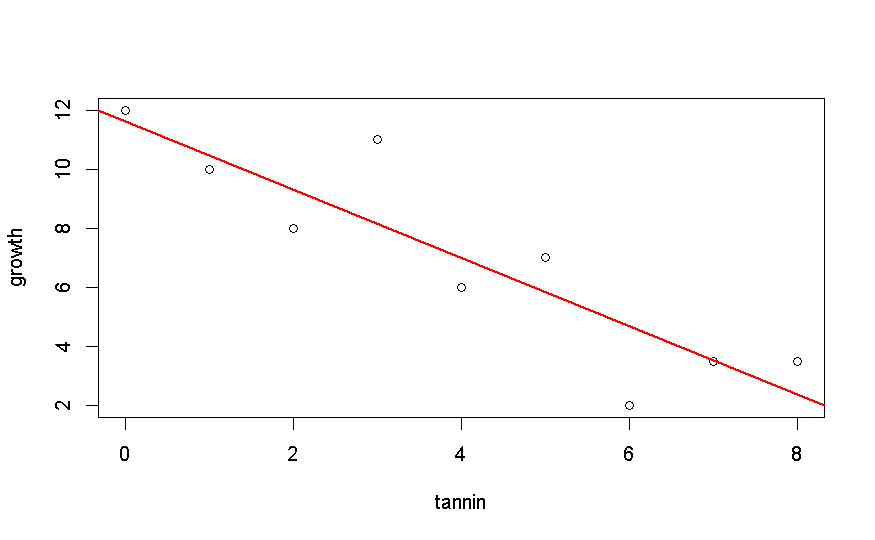

relazione negativa tra l’aumento di tannini nella dieta e la crescita. (lo si capisce dal valore -1-1583, il coefficiente angolare)

A previous experiment, however, produced different results. In particular, the slope of the regression coefficient was -1.5. We can do a test to see if the slope we just estimated (-1.158) is statistically different from 1.5. In this case the null hypothesis is that the slope is -1.5, vs. the alternative hypothesis that the slope is more than -1.5. un collega dell’anno prima rifacendo lo stesso esperimento aveva ottenuto un valore diverso di t, quindi vogliamo vedere se il valore di t è significativamente più grande di -1.5. QUindi qui l’esercizio mi sta chiedendo espressamente di fare un test a una coda.0.2236 è l’errore standard.

[output not shown]

[1] 0.08515618

[output not shown]

```
                2.5 %     97.5 %
(Intercept)  9.116248 14.1504183
tannin      -1.687027 -0.6296397
```

ora torniamo alle slide e introduciamo i test sugli assunti (slide 9), che va fatto dopo perchè i nostri assunti sulla regressione si basano sui residui, su quanto i punti si disconstano dalla retta.